# Part4

## Question 1

```r
library(igraph)
```

### Question (a)

Modularity measures a statistically surprising arrangement of edges in a graph. It is (up to a multiplicative constant) the difference between the **actual** number of edges falling between two groups minus the **expected** number of edges falling within groups for a random network.

### Question (b)

The adjacency matrix of this graph is
$$\mathbf{A} = \left[
\begin{array}{cccccc}
0 & 1 & 1 & 0 & 0 & 0 \\
1 & 0 & 1 & 0 & 0 & 0 \\
1 & 1 & 0 & 1 & 0 & 0 \\
0 & 0 & 1 & 0 & 1 & 1 \\
0 & 0 & 0 & 1 & 0 & 1 \\
0 & 0 & 0 & 1 & 1 & 0
\end{array}
\right]$$
So we can use function `graph_from_adjacency_matrix` to build the graph in `igraph`

```r
A = matrix(0, nrow=6, ncol=6)
# node 1
A[1,2] = 1
A[1,3] = 1
# node 2
A[2,1] = 1
A[2,3] = 1
# node 3
A[3,1] = 1
A[3,2] = 1
A[3,4] = 1
# node 4
A[4,3] = 1
A[4,5] = 1
A[4,6] = 1
# node 5
A[5,4] = 1
A[5,6] = 1
# node 6
A[6,4] = 1
A[6,5] = 1

print(A)
```

```
##      [,1] [,2] [,3] [,4] [,5] [,6]
## [1,]    0    1    1    0    0    0
## [2,]    1    0    1    0    0    0
## [3,]    1    1    0    1    0    0
## [4,]    0    0    1    0    1    1
## [5,]    0    0    0    1    0    1
## [6,]    0    0    0    1    1    0
```

```r
g = graph_from_adjacency_matrix(A)
```

The modularity matrix $\mathbf{B}$ is the obtained with function `modularity_matrix`

```r
B = modularity_matrix(g)
print(B)
```

```
##            [,1]       [,2]       [,3]       [,4]       [,5]       [,6]
## [1,] -0.2857143  0.7142857  0.5714286 -0.4285714 -0.2857143 -0.2857143
## [2,]  0.7142857 -0.2857143  0.5714286 -0.4285714 -0.2857143 -0.2857143
## [3,]  0.5714286  0.5714286 -0.6428571  0.3571429 -0.4285714 -0.4285714
## [4,] -0.4285714 -0.4285714  0.3571429 -0.6428571  0.5714286  0.5714286
## [5,] -0.2857143 -0.2857143 -0.4285714  0.5714286 -0.2857143  0.7142857
## [6,] -0.2857143 -0.2857143 -0.4285714  0.5714286  0.7142857 -0.2857143
```

We then calculate the leading eigenvector of the matrix and use its signs to choose the membership of each node. We then use it to calculate the modularity of the split.

```r
v = eigen(B)$vectors[,1]
print(v)
```

```
## [1] -0.4440369 -0.4440369 -0.3250576  0.3250576  0.4440369  0.4440369
```

```r
membership = rep(0, length(v))
membership[v < 0] = 1
membership[v > 0] = 2
M = modularity(g, membership)
print(M)
```

```
## [1] 0.3571429
```

### Question (c)

The **magnitude of the coordinates** of the eigenvector can be used to give the degree of certitude when assigning a class to a node. In the case of this graph, we see that nodes 3 and 4 are those with smaller magnitude as compared to other nodes. This makes sense, since these nodes are the ones in the frontier between the two classes.

### Question (d)

If we wanted to split the network into more than two classes, we could redo the previous spectral algorithm on each sub-graph. In other words, we would calculate a new modularity matrix $\mathbf{B}_1$ for nodes in class 1 and a matrix $\mathbf{B}_2$ for nodes in class 2. In this setting, if $\mathbf{B}_1$ had no positive eigenvalues (i.e. > 0) but $\mathbf{B}_2$ did, then we could have a split we three communities.

### Question (e)

When the eigenvalues of the modularity matrix are all negative, it indicates that the best split is the one with eigenvalue equal to zero. This eigenvalue is associated to the eigenvector full of ones, meaning that the graph should not be split into two communities.

## Question 2

### Question (a)

We start with building the adjacency matrix for the graph of interest

```r
A = matrix(0, nrow=5, ncol=5)
# node 1
A[1,2] = 1
A[1,4] = 1
# node 2
A[2,1] = 1
A[2,3] = 1
A[2,4] = 1
# node 3
A[3,2] = 1
A[3,4] = 1
A[3,5] = 1
# node 4
A[4,1] = 1
A[4,2] = 1
A[4,3] = 1
A[4,5] = 1
# node 5
A[5,3] = 1
A[5,4] = 1

print(A)
```

```
##      [,1] [,2] [,3] [,4] [,5]
## [1,]    0    1    0    1    0
## [2,]    1    0    1    1    0
## [3,]    0    1    0    1    1
## [4,]    1    1    1    0    1
## [5,]    0    0    1    1    0
```

We then create a similarity matrix in which each coordinate $(i,j)$ has the cosine similarity between two nodes of the graph
$$\mathbf{\sigma}_{ij} = \dfrac{\mathbf{A}_i^\top
\mathbf{A}_j}{\|\mathbf{A}_i\| \times \|\mathbf{A}_j\|}$$
The code for building it is then

```r
S = matrix(0, nrow=5, ncol=5)
for(i in 1:5)
{
  for(j in 1:5)
  {
    S[i,j] = (A[i,] %*% A[j,]) / ( sqrt(A[i,] %*% A[i,]) * sqrt(A[j,] %*% A[j,]) )
  }
}
print(S)
```

```
##           [,1]      [,2]      [,3]      [,4]      [,5]
## [1,] 1.0000000 0.4082483 0.8164966 0.3535534 0.5000000
## [2,] 0.4082483 1.0000000 0.3333333 0.5773503 0.8164966
## [3,] 0.8164966 0.3333333 1.0000000 0.5773503 0.4082483
## [4,] 0.3535534 0.5773503 0.5773503 1.0000000 0.3535534
## [5,] 0.5000000 0.8164966 0.4082483 0.3535534 1.0000000
```

### Question (b)

The function `hclust` requires a distance matrix as input and not a similarity one.

We therefore make $\mathbf{D} = 1 - \boldsymbol{\Sigma}$ and use it as input argument. Note that it is important to use `as.dist` to cast a numerical matrix as a distance matrix for `hclust` to run properly.

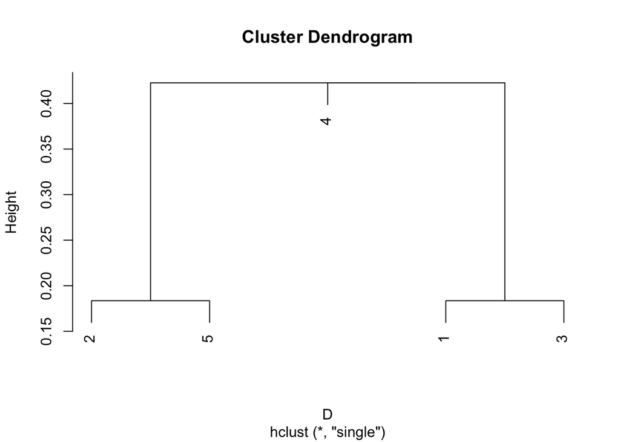

```r
D = as.dist(1 - S)
hc = hclust(D, method="single")
plot(hc)
```